# R Notebook

```r
install.packages("tidyverse")
library(ggplot2)
install.packages("ggpubr")
library(ggpubr)
```

2.Load in the data as an object called DublinAirport. Notice that you have to skip the first 19 lines contained in the file before beginning to read data. Line 20 contains the column names. Display the structure of the dataset

```r
DublinAirport = read.csv("mly532.csv",header = T, skip = 19)
str(DublinAirport)
```

```
'data.frame':   931 obs. of  12 variables:
 $ year : int  1941 1941 1942 1942 1942 1942 1942 1942 1942 1942 ...
 $ month: int  11 12 1 2 3 4 5 6 7 8 ...
 $ meant: num  6.9 6.5 4.3 2.9 6.3 8.4 10.4 13.1 14.6 14.9 ...
 $ maxtp: num  14 12.7 11.9 11.6 16.2 16.2 20.9 24.1 22.2 22.3 ...
 $ mintp: num  -3.1 -3.6 -3.1 -4.3 -6.1 0.8 1.8 1.4 7.2 6.7 ...
 $ mnmax: num  9.9 9.1 6.9 5.8 9.4 11.9 14.4 18 18.9 18.4 ...
 $ mnmin: num  3.9 3.9 1.7 0 3.2 4.9 6.3 8.2 10.4 11.4 ...
 $ rain : num  67.2 41.7 91.9 25.8 76.4 ...
 $ gmin : num  -5.7 -7.6 -9.5 -10.7 -8.3 -0.4 -0.7 -0.9 2.4 4.6 ...
 $ wdsp : num  12 12.5 13.1 9 10.7 15.1 12 9.4 13.4 10.8 ...
 $ maxgt: int  NA NA NA NA NA NA NA NA NA NA ...
 $ sun  : num  56.1 46.1 72.8 51.4 73.9 ...
```

3.Transform the column months to a factor with labels given by the month names. [Two hints: (1) look at the arguments levels and labels of the function factor. (2) you may want to make use of the built-in constant month.name]

```r
DublinAirport$month <- factor(DublinAirport$month,levels = c(1,2,3,4,5,6,7,8,9,10,11,12),labels = month.name)
```

4.Use the aggregate function to compute which month has on average the highest and the lowest Precipitation Amount.

```r
res = aggregate(rain~month,aa,sum)
res[order(res$rain),]
```

|  | month | rain |
| --- | --- | --- |
| 2 | February | 3876.8 |
| 4 | April | 3927.9 |
| 3 | March | 4063.7 |
| 7 | July | 4471.1 |
| 5 | May | 4538.9 |
| 6 | June | 4547.4 |
| 1 | January | 5194.2 |
| 9 | September | 5220.8 |
| 10 | October | 5527.0 |
| 11 | November | 5540.8 |

[output cut: 2 more lines]

5.Create a new column which contains a factor indicating the season: • Winter: December, January, February, • Spring: March, April, May, • Summer: June, July, August, • Autumn: September, October, November [Hint: again, look at the arguments levels and labels of the function factor.]

```r
DublinAirport$season <- factor(aa$month, levels =month.name[c(12,1,2,3,4,5,6,7,8,9,10,11)],labels = c("Winter","Winter","Winter","Spring","Spring","Spring","Summer","Summer","Summer","Autumn","Autumn","Autumn"))
```

6. Assign to the DublinAiport object the classes WeatherData and data.frame.

```r
class(DublinAirport) = c("WeatherData","data.frame")
```

7. Write an S3 summary method for an object of class WeatherData which produces the following statistical summaries the rain, maxtp, mintp, maxgt variables split by season: mean, standard deviation, minimum, maximum. Ignore the missing values in the calculations. Test your function on the DublinAirport data set and comment your findings

```r
summary.WeatherData = function(obj){
  Mean_statistic = aggregate(cbind(obj$rain,obj$maxtp,obj$mintp,obj$maxgt), by =list(obj$season),FUN = mean, na.rm = T)
  SD_statistic = aggregate(cbind(obj$rain,obj$maxtp,obj$mintp,obj$maxgt), by = list(obj$season), FUN = sd, na.rm = T)
  Minimum_statistic = aggregate(cbind(obj$rain,obj$maxtp,obj$mintp,obj$maxgt), by = list(obj$season), FUN = min, na.rm = T)
  Maximum_statistic = aggregate(cbind(obj$rain,obj$maxtp,obj$mintp,obj$maxgt), by = list(obj$season), FUN = max, na.rm = T)
  colnames(Mean_statistic) = c("Seasons","Rain_mean","Maxtp_mean","Mintp_mean","Maxgt_mean")
  colnames(SD_statistic) = c("Seasons","Rain_SD","Maxtp_SD","Mintp_SD","Maxgt_SD")
  colnames(Minimum_statistic) = c("Seasons","Rain_min","Maxtp_min","Mintp_min","Maxgt_min")
  colnames(Maximum_statistic) = c("Seasons","Rain_max","Maxtp_max","Mintp_max","Maxgt_max")
  print(Mean_statistic)
  print(SD_statistic)
  print(Minimum_statistic)
  print(Maximum_statistic)
}
summary.WeatherData(DublinAirport)
```

| Seasons | Rain_mean | Maxtp_mean | Mintp_mean | Maxgt_mean |
| --- | --- | --- | --- | --- |
| Winter | 63.89017 | 12.73761 | -3.1931624 | 53.04933 |
| Spring | 53.54915 | 17.16239 | -0.5871795 | 45.57333 |
| Summer | 63.92165 | 23.02511 | 5.9303030 | 39.49333 |
| Autumn | 70.20948 | 18.02198 | 1.2551724 | 47.23661 |

| Seasons | Rain_SD | Maxtp_SD | Mintp_SD | Maxgt_SD |
| --- | --- | --- | --- | --- |
| Winter | 32.87200 | 1.638288 | 2.369322 | 8.767892 |
| Spring | 27.30880 | 2.798734 | 2.401950 | 7.426136 |
| Summer | 35.43135 | 1.787048 | 1.735196 | 6.263642 |
| Autumn | 38.11011 | 3.038054 | 2.799624 | 7.875278 |

| Seasons | Rain_min | Maxtp_min | Mintp_min | Maxgt_min |
| --- | --- | --- | --- | --- |
| Winter | 4.7 | 4.8 | -12.2 | 35 |
| Spring | 3.6 | 9.9 | -7.9 | 28 |
| Summer | 4.0 | 18.4 | 0.7 | 27 |
| Autumn | 3.6 | 12.1 | -8.4 | 27 |

| Seasons | Rain_max | Maxtp_max | Mintp_max | Maxgt_max |
| --- | --- | --- | --- | --- |
| Winter | 217.0 | 17.1 | 1.8 | 80 |
| Spring | 151.8 | 23.5 | 6.9 | 66 |
| Summer | 189.9 | 28.7 | 10.0 | 56 |
| Autumn | 185.8 | 25.1 | 7.5 | 73 |

8. Create an S3 plot method for the class WeatherData that produces the following plots.
1. Plot of the monthly Air Temperature (C) (maxtp, mintp).
2. Plot of the Precipitation Amount (mm) (rain).
3. Plot of the Highest Gust (knot) (maxgt). • The user must be able to decide which years to plot. By default it will use the data from 2015 until 2018. • The user must be able to decide which plot to draw (i.e, only one of the three, two of the three, or all three plots). By default the function will create all three plots. • The plots must be on a single panel. • The plots must have meaningful labels and/or titles, and a legend if needed. • Test your function on the DublinAirport data set

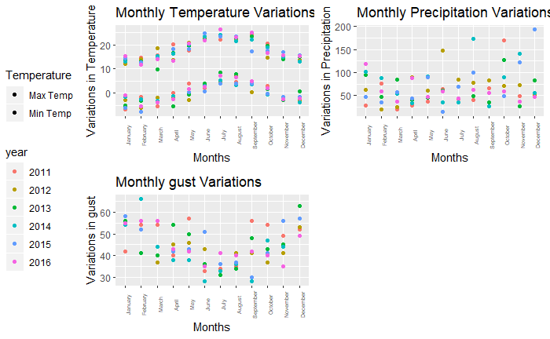

```r
plot.WeatherData = function(obj,Begin_year = "2015",End_year = "2018", plot = "X"){
  Duration = subset(obj,obj$year>= Begin_year & obj$year <= End_year)
  Duration$year = as.factor(Duration$year)
  shapes = c("Q1" = 16,"Q2" = 19)
 g1 = ggplot(data = Duration,mapping=aes(x=month))+
   geom_point(aes(y=maxtp,colour=year,shape = "Q1")) +
   geom_point(aes(y=mintp,colour=year,shape = "Q2")) +
   labs(x="Months",y="Variations in Temperature", title= "Monthly Temperature Variations")+
   theme(axis.text.x = element_text(angle = 90,size = 5))+
   scale_shape_manual(name="Temperature",breaks = c("Q1","Q2"),values = shapes,labels = c("Max Temp", "Min Temp"))
  g2 = ggplot(data = Duration,mapping=aes(x=month))+
     geom_point(aes(y=rain,colour=year)) +
   labs(x="Months", y="Variations in Precipitation", title= "Monthly Precipitation Variations")+
    theme(axis.text.x = element_text(angle = 90,size = 5))
  g3 = ggplot(data = Duration,mapping=aes(x=month))+
     geom_point(aes(y=maxgt,colour=year)) +
   labs(x="Months", y="Variations in gust", title= "Monthly gust Variations")+
    theme(axis.text.x = element_text(angle = 90,size = 5))
  if(plot=="1"){
    ggarrange(g1,common.legend = TRUE, legend = "left")
  }
  else if(plot=="2"){
    ggarrange(g1,g2,common.legend = TRUE, legend = "left")
  }else if(plot=="3"|plot == "X"){
    ggarrange(g1,g2,g3,common.legend = TRUE, legend = "left")
  }
}

plot.WeatherData(obj=DublinAirport,Begin_year = "2011",End_year = "2016")
```